# Eksploracja danych Api Allegro

Michał Stawikowski

3 marca 2019

# Wstęp

W tym raporcie postaram się przeprowadzić eksplorację danych pochodzących z jednego dnia, uzyskanych z API Allegro. Użyję do tego bazowych funkcji `R`, podstawowych pakietów takich jak `ggplot2`, czy `dplyr` oraz bardziej zaawansowanych, przeznaczonych do eksploracji dancych pakietów `visdat` oraz `dataMaid`. Dwa ostatnie wymienione pakiety pomagają w automatyzacji analizy danych. Dane opisują zamówienia z serwisu Allegro na przestrzenie jednego dnia. Zmienne zawierają informacje min:. o cenach zamówionych produktów, ilości zamówień, czy ocenach sprzedających.

# Podsumowanie numeryczne oraz sprawdzenie poprawności danych

## Bazowa funckcja `summary`

```r
summary(final$price)
```

```
##      Min.   1st Qu.    Median      Mean   3rd Qu.      Max.      NA's
##      0.00      9.00     24.99     76.81     68.45 119000.00         8
```

```r
summary(final$it_is_allegro_standard)
```

```
##    Min. 1st Qu.  Median    Mean 3rd Qu.    Max.    NA's
##  0.0000  0.0000  1.0000  0.5835  1.0000  1.0000       8
```

```r
summary(final$it_is_brand_zone)
```

```
##    Min. 1st Qu.  Median    Mean 3rd Qu.    Max.    NA's
## 0.00000 0.00000 0.00000 0.01669 0.00000 1.00000       8
```

```r
summary(final$it_seller_rating)
```

```
##    Min. 1st Qu.  Median    Mean 3rd Qu.    Max.    NA's
##      -1    1581    6711   20403   21007  292074       8
```

```r
summary(final$date)
```

```
##                  Min.               1st Qu.                Median
## "2016-04-03 00:00:09" "2016-04-03 12:50:14" "2016-04-03 17:12:25"
##                  Mean               3rd Qu.                  Max.
## "2016-04-03 16:24:21" "2016-04-03 20:14:39" "2016-04-03 23:59:59"
##                  NA's
##                   "8"
```

```r
summary(final$pay_option_on_delivery)
```

```
##    Min. 1st Qu.  Median    Mean 3rd Qu.    Max.    NA's
##   0.000   1.000   1.000   0.878   1.000   1.000       8
```

```r
summary(final$pay_option_transfer)
```

```
##    Min. 1st Qu.  Median    Mean 3rd Qu.    Max.    NA's
##  0.0000  1.0000  1.0000  0.8125  1.0000  1.0000       8
```

Podsumowanie dla głównych zmiennych ramki danych.

## Analiza poprawności i podsumowanie przy użyciu pakietu `datavis`

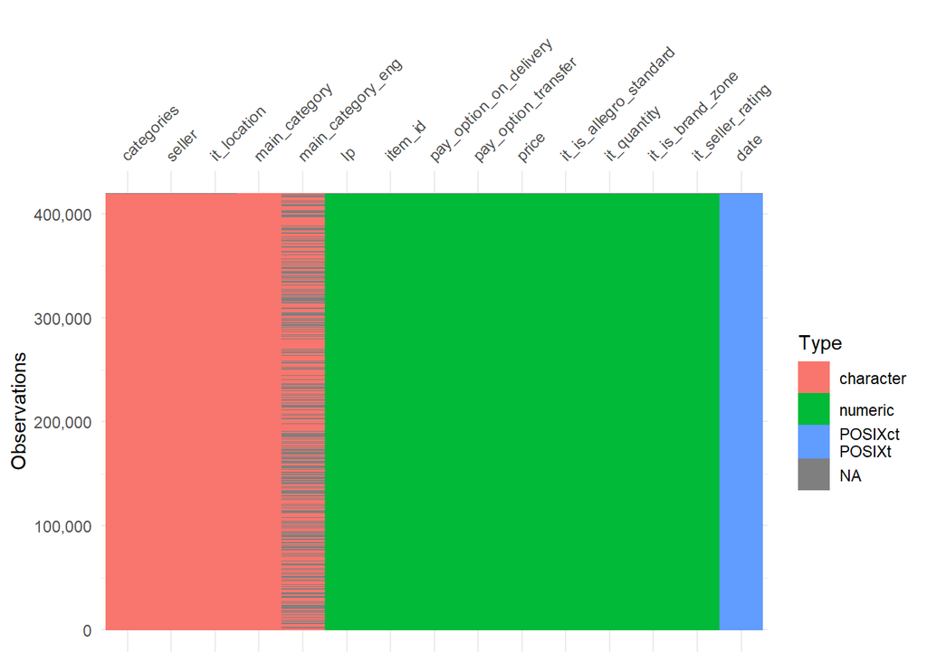

```r
vis_dat(final, warn_large_data = FALSE) + scale_y_continuous(labels = comma)
```

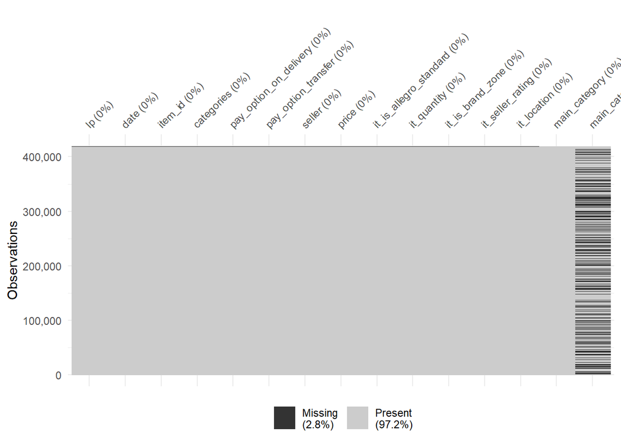

```r
vis_miss(final,warn_large_data = FALSE) + scale_y_continuous(labels = comma)
```

Funkcja `vis_dat` zwraca nam prosty opis danych z podziałem na kategorie zmiennych, zaś funkcja `vis_miss` skupia się na brakujących danych. Niestety pakiet nie jest do końca przystosowany do danych dużych rozmiarów i dość bezwzględnie zaokrągla wyniki obliczeń przez co tracimy część informacji. Wizualizacje są przyjemne dla oka, a funkcje proste w użyciu, aoutomatyzują część pracy przy eksploracji danych.

## Pakiet `ggplot2` i funckje bazowe

### Zmienna `price`

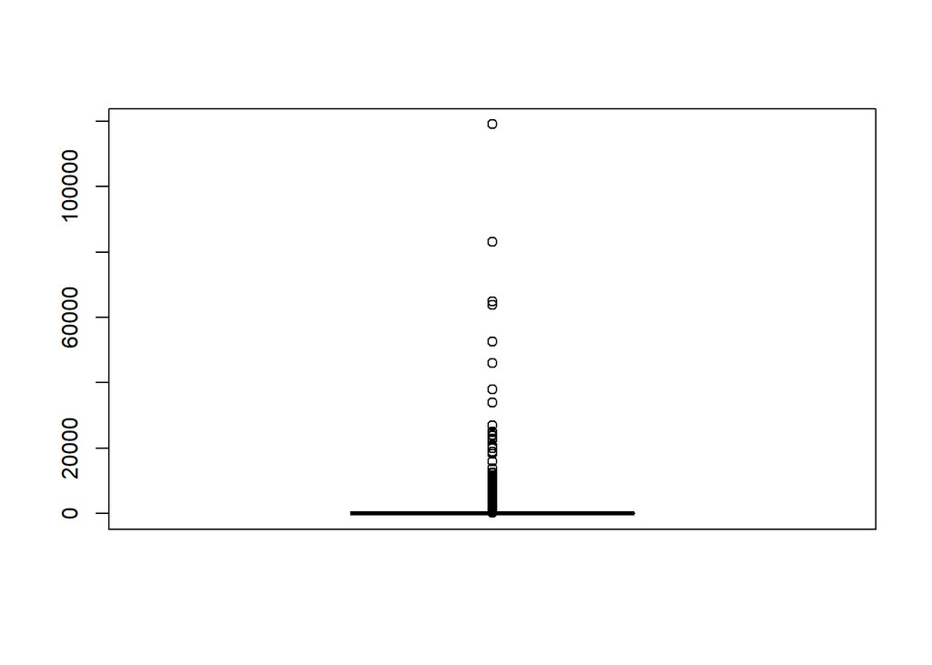

```r
boxplot(final$price)
```

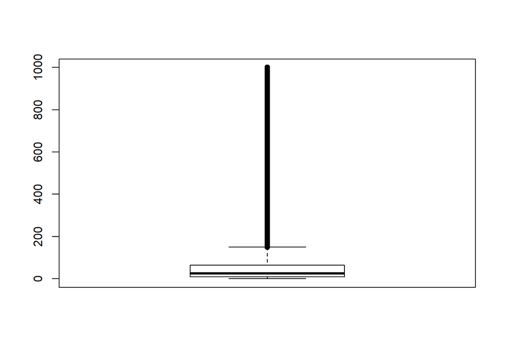

```r
ograniczonaCena <- final$price[final$price<1000]
boxplot(ograniczonaCena)
```

Jak widać na boxplotach cena skupia się głównie w przedziale od 0 do 1000 zł, dlatego też drugi boxplot przedstawia dane ograniczone właśnie do tych wartości, dzięki temu możemy lepiej przeanalizować rozkład cen.

### Zmienna `Seller rating`

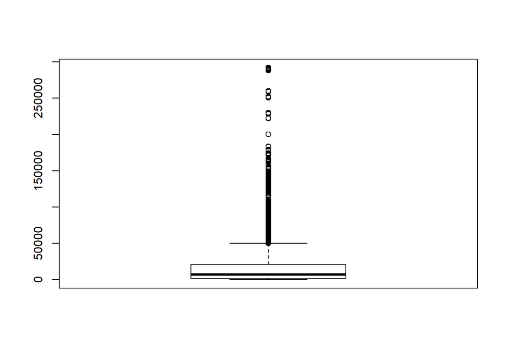

```r
boxplot(final$it_seller_rating)
```

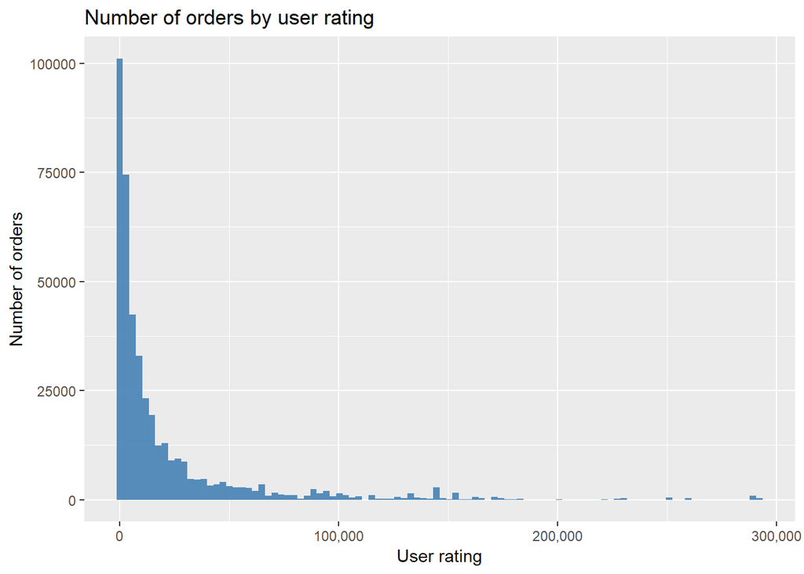

```r
ggplot(final,aes(x=final$it_seller_rating)) + geom_histogram(bins = 100,fill="steelblue",alpha=0.9) +
  scale_x_continuous(labels = comma) +
  xlab("User rating") + ylab("Number of orders") + ggtitle("Number of orders by user rating")
```

Oceny sprzedawców też, tak samow jak cena skupione są przy mniejszych wartościach, jednak nie występują wartości aż tak odstające jak w przypadku poprzedniej zmiennej.

### Zmienna `Allegro standard`

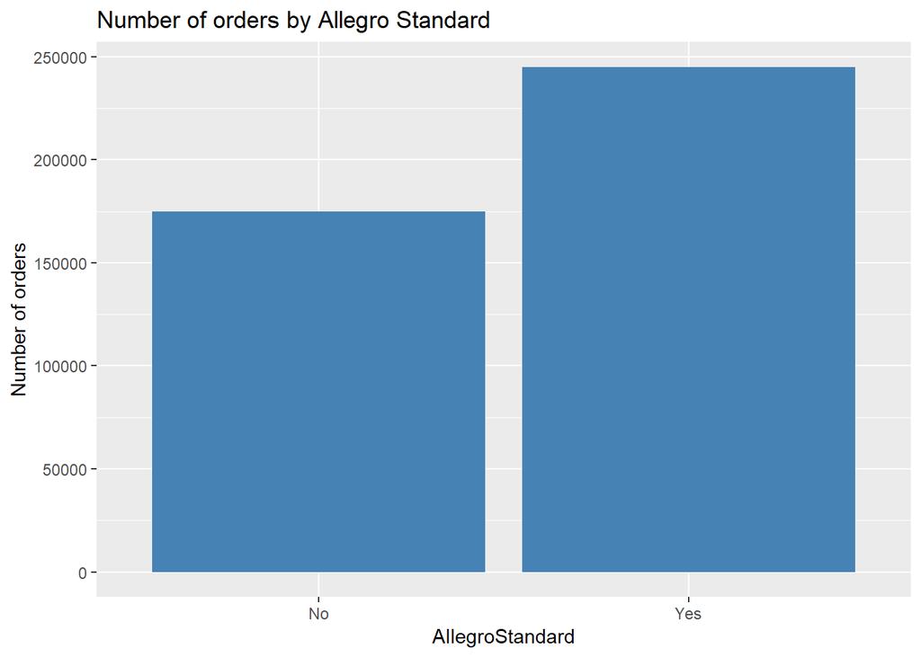

```r
Yes <- sum(na.omit(final$it_is_allegro_standard))
Noo <- length(na.omit(final$it_is_allegro_standard)) - Yes
Liczba <- c(Yes,Noo)
AllegroStandard <- c("Yes", "No")
Standard <- data.frame(Liczba,AllegroStandard)

ggplot(data=Standard, aes(x=AllegroStandard, y=Liczba)) + geom_bar(stat = "identity",fill="steelblue") +
  ylab("Number of orders") + ggtitle("Number of orders by Allegro Standard")
```

Nie jest to najciekawsza zmienna do analizowania, jednak z wykresu słupkowego widać, że większość zamówień posiada standard Allegro.

### Zmienna `Brand Zone`

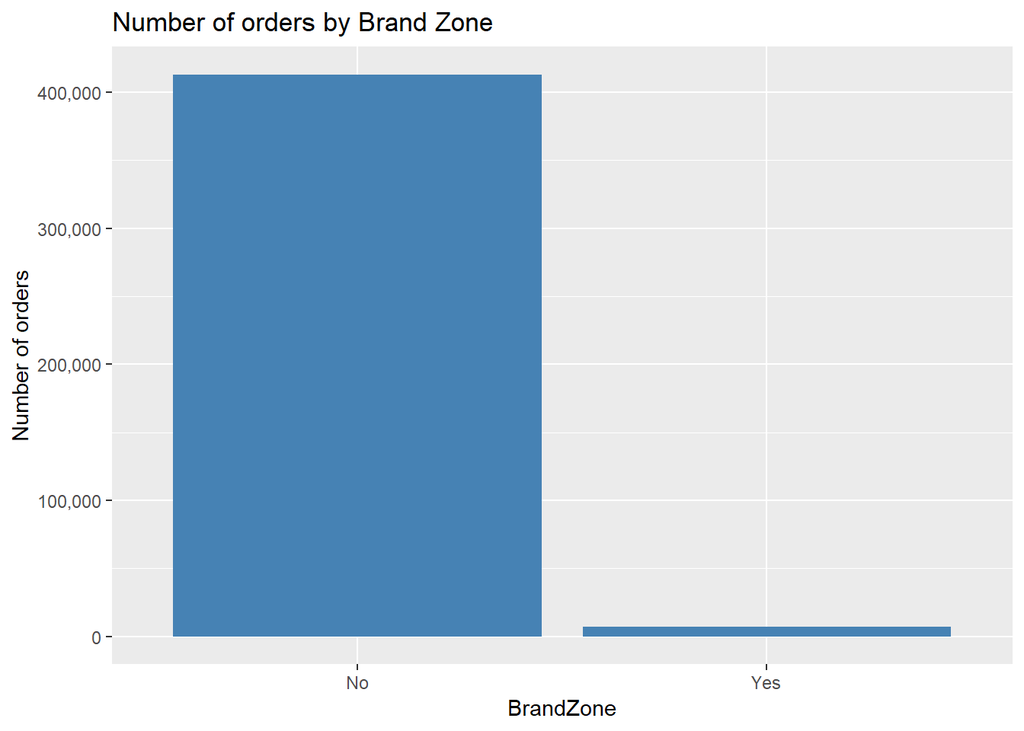

```r
Yes <- sum(na.omit(final$it_is_brand_zone))
Noo <- length(na.omit(final$it_is_brand_zone)) - Yes
Liczba <- c(Yes,Noo)
BrandZone <- c("Yes", "No")
Standard <- data.frame(Liczba,BrandZone)

ggplot(data=Standard, aes(x=BrandZone, y=Liczba)) + geom_bar(stat = "identity",fill="steelblue") +
  ylab("Number of orders") + scale_y_continuous(labels = comma) + ggtitle("Number of orders by Brand Zone")
```

### Zmienne dotyczące opcji płatności.

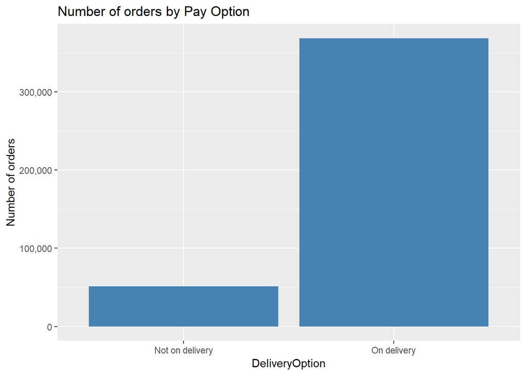

```r
Yes <- sum(na.omit(final$pay_option_on_delivery))
Noo <- length(na.omit(final$pay_option_on_delivery)) - Yes
Liczba <- c(Yes,Noo)
DeliveryOption <- c("On delivery", "Not on delivery")
Standard <- data.frame(Liczba,DeliveryOption)

ggplot(data=Standard, aes(x=DeliveryOption, y=Liczba)) + geom_bar(stat = "identity",fill="steelblue") +
  ylab("Number of orders") + ggtitle("Number of orders by Pay Option")+ scale_y_continuous(labels = comma)
```

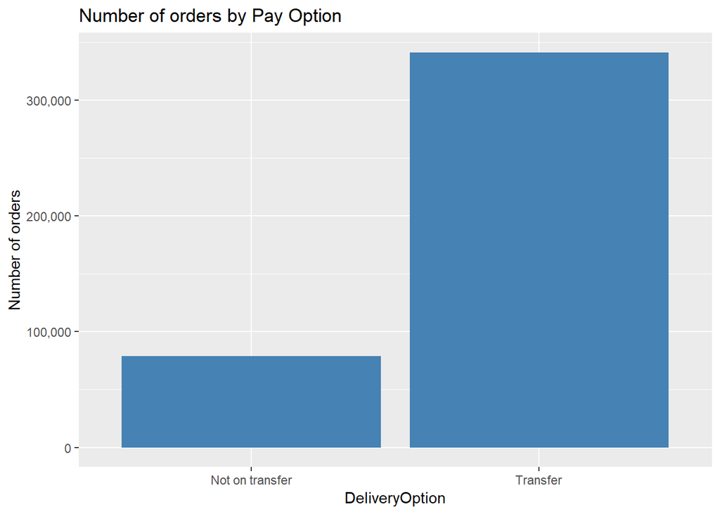

```r
Yes <- sum(na.omit(final$pay_option_transfer))
Noo <- length(na.omit(final$pay_option_transfer)) - Yes
Liczba <- c(Yes,Noo)
DeliveryOption <- c("Transfer", "Not on transfer")
Standard <- data.frame(Liczba,DeliveryOption)

ggplot(data=Standard, aes(x=DeliveryOption, y=Liczba)) + geom_bar(stat = "identity",fill="steelblue") +
  ylab("Number of orders") + ggtitle("Number of orders by Pay Option")+ scale_y_continuous(labels = comma)
```

Zmienne odpowiadające za sposób płatności wyglądają tak, jakby nie były wykluczające się. Sprawdźmy to przy użyciu funkcju `vis_compare`.

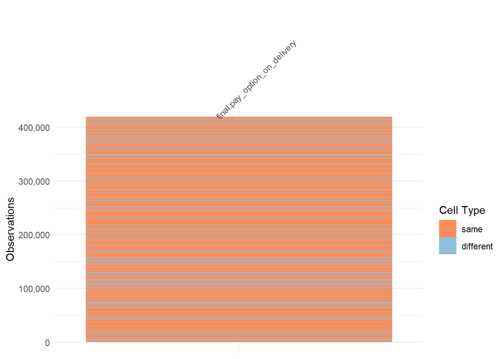

```r
vis_compare(data.frame(final$pay_option_on_delivery),data.frame(final$pay_option_transfer)) + scale_y_continuous(labels = comma)
```

Tak jak widzimy na wykresie większość wartości pokrywa się, co może wskazywać na to, że przelewem można płacić także przy odbiorze.

### Zmienna `Categories`

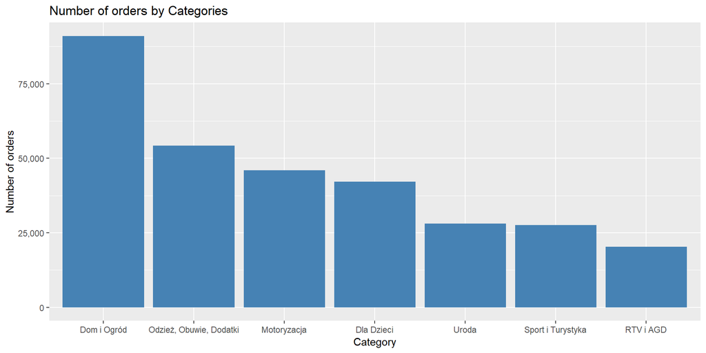

```r
number <- count(final, main_category)
number <- arrange(number, -n)
number <- head(number,7)

ggplot(data=number, aes(x=reorder(number$main_category, -number$n), y=number$n)) + geom_bar(stat = "identity",fill="steelblue") +
  ylab("Number of orders") + ggtitle("Number of orders by Categories")+ scale_y_continuous(labels = comma) + xlab("Category")
```

Na tym wykresie słupkowym zostały przedstawione najpopularniejsze kategorie pod względem ilości zamóWień.

### Zmienna `Location`

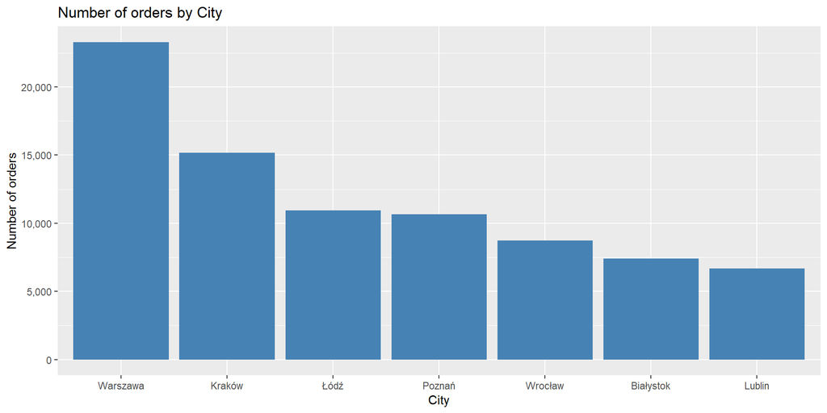

```r
number <- count(final, it_location)
number <- arrange(number, -n)
number <- head(number,7)

ggplot(data=number, aes(x=reorder(number$it_location, -number$n), y=number$n)) + geom_bar(stat = "identity",fill="steelblue") +
  ylab("Number of orders") + ggtitle("Number of orders by City")+ scale_y_continuous(labels = comma) + xlab("City")
```

Z tego wykresu możemy przekonać się skąd pochodzi większość zamówień. Przedstawione zostało 7 miast z największą ilością zamówień.

### Zmienna `Date`

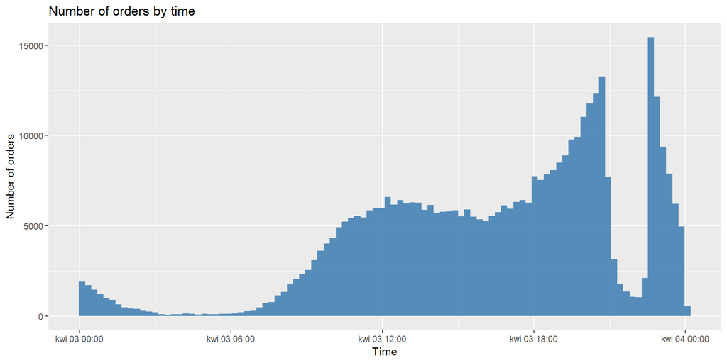

```r
ggplot(final, aes(x=as.POSIXct(final$date, format = "%H:%M:%S"))) +
  geom_histogram(bins = 100,fill="steelblue",alpha=0.9) +
  xlab("Time") + ylab("Number of orders") + ggtitle("Number of orders by time")
```

To jedna z ciekaszych zmiennych do analizowania, dzięki niej możemy się przekonać, kiedy klienci najczęściej dokonują zakpupów oraz znależć takie anomalie jak spadek ilości zamówień około godziny 22:00. Liczba zamówiń rośnie od rana by osiągnąć maksima w godzinach nocnych, kiedy większość ludzi prawdopodobnie skończła pracę i wróciła do domów.

### Zmienna `Seller`

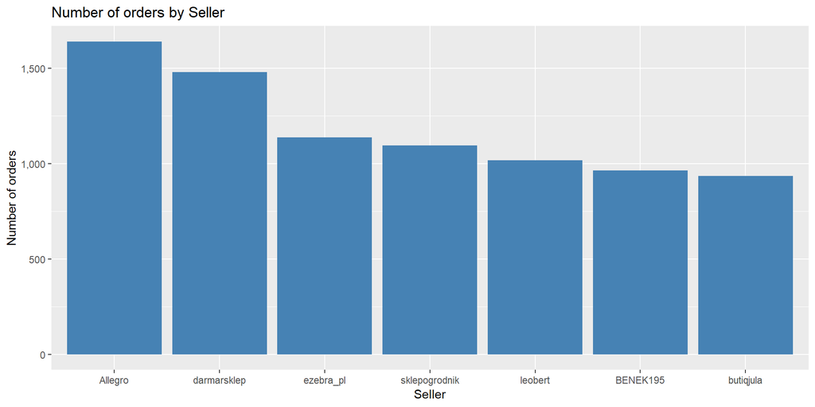

```r
number <- count(final, seller)
number <- arrange(number, -n)
number <- head(number,7)

ggplot(data=number, aes(x=reorder(number$seller, -number$n), y=number$n)) + geom_bar(stat = "identity",fill="steelblue") +
  ylab("Number of orders") + ggtitle("Number of orders by Seller")+ scale_y_continuous(labels = comma) + xlab("Seller")
```

Z tego wykresu możemy odczytać, że pod względem zamówień tego dnia najlepiej poradziły sobie różne sklepy internetowe jak i samo Allegro, chociaż wnioskując po nickach możliwe, że wśród 7 sprzedawców z największą ilością zamówień znaleźli się też indywidualni użytkownicy.

## Zależności wielu zmiennych

### Zależność `price` od `category`

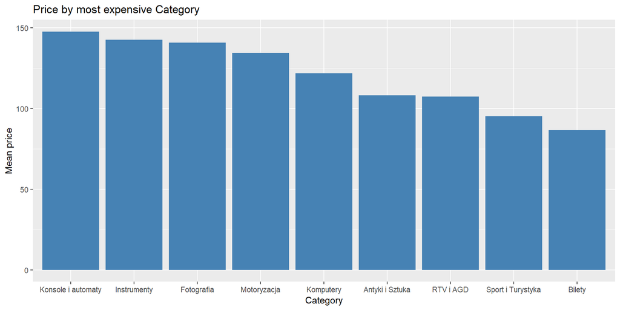

```r
final2 <- na.omit(final)
agg <- aggregate(final2$price, list(final2$main_category), mean)
agg <- arrange(agg, -x)

#most expensive
agg1 <- head(agg,9)

ggplot(data=agg1, aes(x=reorder(agg1$Group.1, -agg1$x), y=agg1$x)) + geom_bar(stat = "identity",fill="steelblue") +
  ylab("Mean price") + ggtitle("Price by most expensive Category")+ scale_y_continuous(labels = comma) + xlab("Category")
```

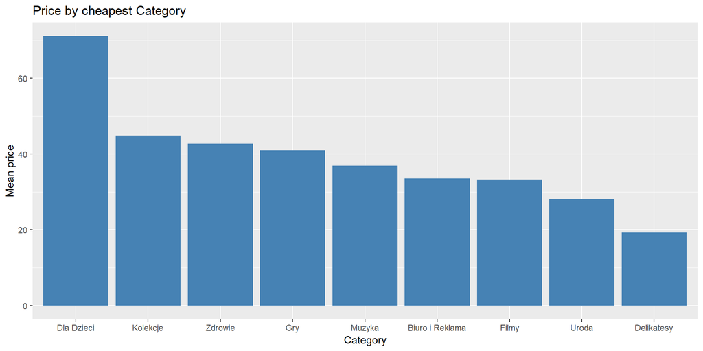

```r
agg2 <- tail(agg,9)

ggplot(data=agg2, aes(x=reorder(agg2$Group.1, -agg2$x), y=agg2$x)) + geom_bar(stat = "identity",fill="steelblue") +
  ylab("Mean price") + ggtitle("Price by cheapest Category")+ scale_y_continuous(labels = comma) + xlab("Category")
```

Na tych wykresach przedstawione zostały kategorie o największej i najmniejszej średniej ceny produktów.

### Zależność `Seller rating` od `number of orders`

```r
myFreqs <- final %>%
  group_by(seller, it_seller_rating) %>%
  summarise(Freq = n())
myFreqs <- arrange(myFreqs, -Freq)
myFreqs
```

```
## # A tibble: 165,503 x 3
## # Groups:   seller [51,065]
##    seller       it_seller_rating  Freq
##    <chr>                   <dbl> <int>
##  1 Aros_pl                288017   230
##  2 PSC-prepaid              9722   208
##  3 darmarsklep            145143   194
##  4 SmA-Converse             2506   185
##  5 leobert                 89478   151
##  6 darmarsklep            145076   149
##  7 gladi20                 20013   139
##  8 miododajne              11123   129
##  9 animalsvet               1931   126
## 10 NaszeZooPL                605   121
## # ... with 165,493 more rows
```

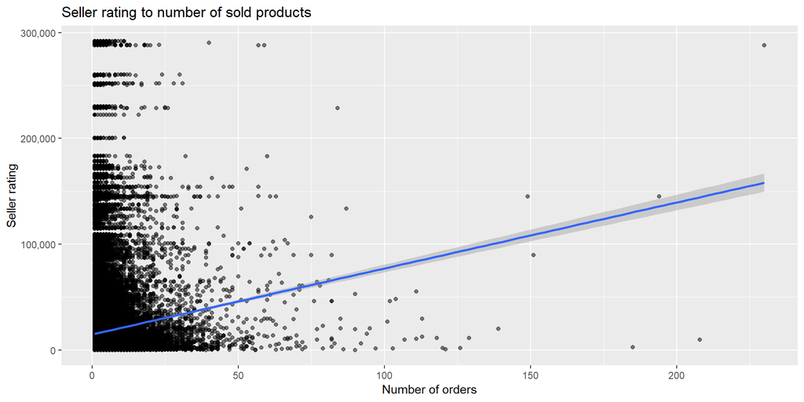

```r
ggplot(data=myFreqs, aes(x=myFreqs$Freq, y=myFreqs$it_seller_rating)) + geom_point(alpha=0.5) +
  geom_smooth(method=lm) + scale_y_continuous(labels = comma) + xlab("Number of orders") + ylab("Seller rating") +
  ggtitle("Seller rating to number of sold products")
```

Z wykresu wynika, że ocena sprzedawcy i liczba obslużonych przez niego zamówień są ze sobą skorelowane. To dość logiczna zależność i wynika prawdopodobnie z faktu, że klienci ufają bardziej sprzedającym z dobrymi opiniami.

### Gross Merchandise Value

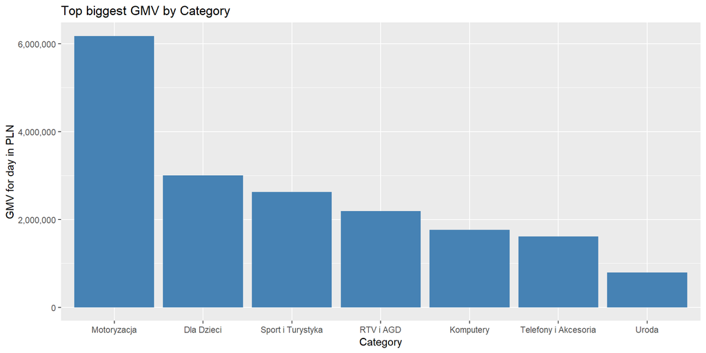

```r
final2 <- na.omit(final)
agg <- aggregate(final2$price, list(final2$main_category), sum)
agg <- arrange(agg, -x)

#most expensive
agg1 <- head(agg,7)


ggplot(data=agg1, aes(x=reorder(agg1$Group.1, -agg1$x), y=agg1$x)) + geom_bar(stat = "identity",fill="steelblue") +
  ylab("GMV for day in PLN") + ggtitle("Top biggest GMV by Category")+ scale_y_continuous(labels = comma) + xlab("Category")
```

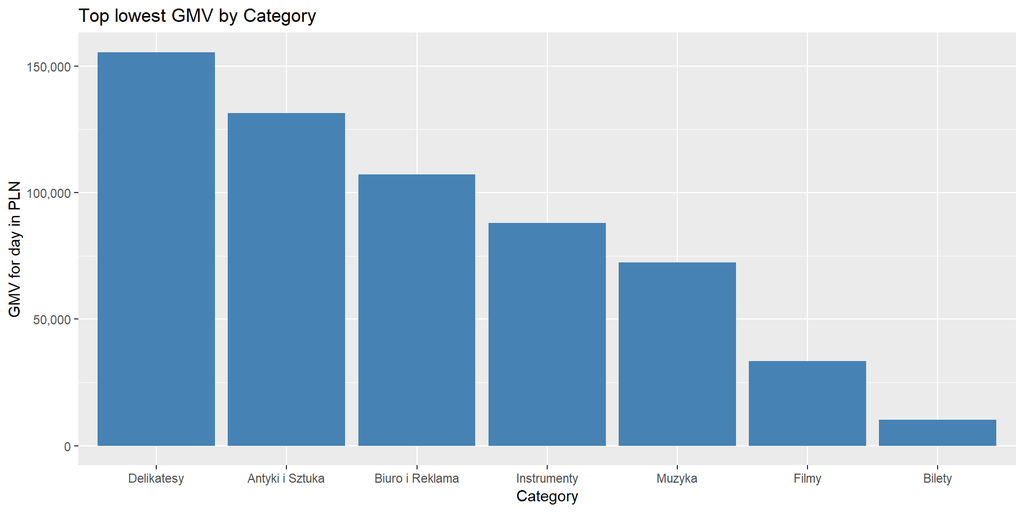

```r
agg2 <- tail(agg,7)

ggplot(data=agg2, aes(x=reorder(agg2$Group.1, -agg2$x), y=agg2$x)) + geom_bar(stat = "identity",fill="steelblue") +
  ylab("GMV for day in PLN") + ggtitle("Top lowest GMV by Category")+ scale_y_continuous(labels = comma) + xlab("Category")
```

Na tych dwóch wykresach możemy odczytać, które kategorie zamówień przynoszą najwięcej i najmniej zysku.

## Zależność zmiennych z funckją `vis_cor`

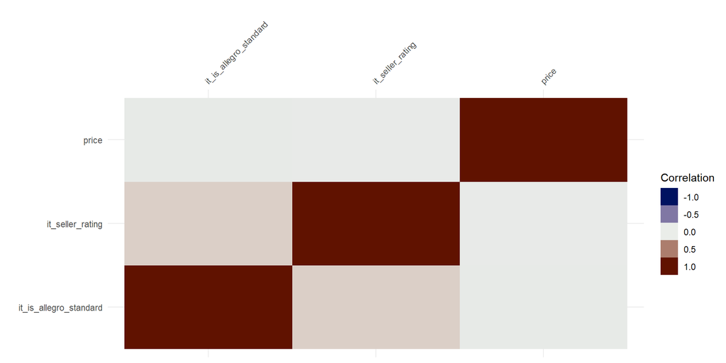

```r
num <- final %>% select(price, it_is_allegro_standard, it_seller_rating)

vis_cor(num,warn_large_data = FALSE)
```

Z tego automatycznie wygenerowanego wykresu możemy odczytać korelacje występujące między zmiennycmi `price`, `it_is_allegro_standard` oraz `it_seller_rating`. Akurat dla tej ramki danych nie znalazłem lepszych zastosowań tej funckji.

## Pakiet `dataMaid`

```r
check(final)
```

```
## $lp
## $lp$identifyMissing
## No problems found.
## $lp$identifyOutliers
## No problems found.
##
## $date
## $date$NoChecksPerformed
## No problems found.
##
## $item_id
## $item_id$identifyMissing
## No problems found.
## $item_id$identifyOutliers
## No problems found.
##
## $categories
## $categories$identifyMissing
## No problems found.
## $categories$identifyWhitespace
## No problems found.
## $categories$identifyLoners
## Note that the following levels have at most five observations: ['Antyki i Sztuka', 'Akcesoria plastyczne', 'Artykuły graficzne'], ['Antyki i Sztuka', 'Akcesoria plastyczne', 'Pozłotnictwo'], ['Antyki i Sztuka', 'Akcesoria plastyczne', 'Przybory rysunkowe', 'Węgiel'], ['Antyki i Sztuka', 'Akcesori…
## $categories$identifyCaseIssues
## No problems found.
## $categories$identifyNums
## No problems found.
##
## $pay_option_on_delivery
## $pay_option_on_delivery$identifyMissing
## No problems found.
## $pay_option_on_delivery$identifyOutliers
## Note that the following possible outlier values were detected: 0.
##
## $pay_option_transfer
## $pay_option_transfer$identifyMissing
## No problems found.
## $pay_option_transfer$identifyOutliers
## Note that the following possible outlier values were detected: 0.
##
```

[output cut: 62 more lines]

```
## No problems found.
## $main_category$identifyNums
## No problems found.
##
## $main_category_eng
## $main_category_eng$identifyMissing
## No problems found.
## $main_category_eng$identifyWhitespace
## The following values appear with prefixed or suffixed white space:  Antiques & Arts,  Automotive,  Babies                        ,  Beauty,  Books and Comics                 ,  Clothing, Shoes, Accessories,  Collections,  Computers,  Consoles,  Crafts (17 additional values omitted).
## $main_category_eng$identifyLoners
## Note that the following levels have at most five observations:  Books and Comics                 ,  Clothing, Shoes, Accessories,  Crafts,  Home & Garden,  Industry,  Jewelry & Watches,  Real Estate  ,  Technics, studio & DJ.
## $main_category_eng$identifyCaseIssues
## No problems found.
## $main_category_eng$identifyNums
## No problems found.
```

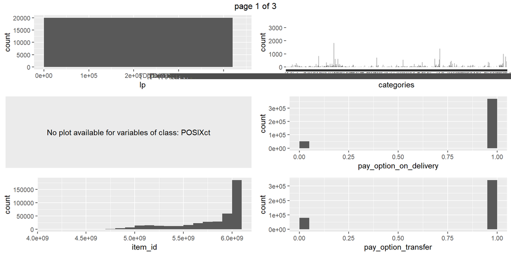

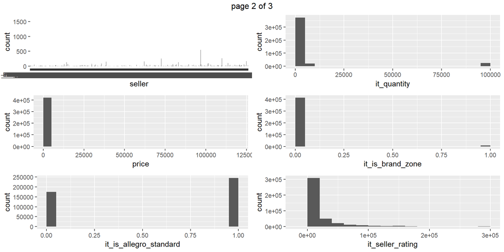

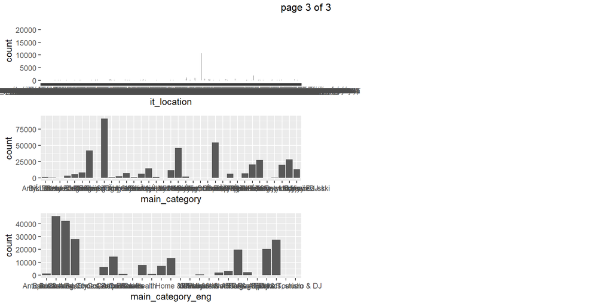

```r
visualize(final)
```

Wyżej wymieniony pakiet pomaga w zautomatyzowaniu przeprowadzania eksploracji dancych, jednak skutkiem ubocznym takiego rozwiązania jest brak wykresów dopracowanych do konkretnych danych i często trudno odczytać informacje z tak powstałych wizualizacji.

# Podsumowanie

Pakiety takie jak `dataMaid` czy `datavis` pomagają w automatyzacji przeprowadzania eksploracji danych, jednak większe możliwości i precyzję dają funckje i wykresy napisane z myślą o konkretnym zestawie danych, czego nie da się osiągnąć przy użyciu wcześniej wymienionych pakietów.